# Week 2: Syntax Guide

- Week 2: Syntax Guide
  - Example Class
  - Class Declaration
  - Constructors
  - Instance method declaration
  - Fields
  - Properties
  - Local Variables
  - Return statement
- Example program
- Modifier Keywords Cheat Sheet

## Example Class

Here is an example class that makes use of the syntax covered in this week.

```
public class MyRectangle
{
  // Fields to store the location of the MyRectangle object
  private int _x;
  private int _y;

  // Properties to access these fields.
  public int X
  {
    get { return _x; }
    set { _x = value; }
  }

  public int Y
  {
    get { return _y; }
    set { _y = value; }
  }

  // Examples of an auto-property. Where C# adds the code and fields for you.

  public int Width { get; set; }
  public int Height { get; set; }
  public Color DrawColor { get; set; }

  // A constructor that takes in data to position the My Rectangle object
  public MyRectangle(int x, int y)
  {
    _x = x; //set the field directly
    Y = y;  // or you can set it via the property.

    Width = 100; // Auto properties can only be accessed via the property
    Height = 50; // here we are using fixed values for the width and height.
    DrawColor = Color.Blue;
  }

  // Get the MyRectangle object to draw itself.
  public void Draw()
  {
    // Use SplashKit to draw, pass in the values read from the fields
    SplashKit.DrawRectangle(DrawColor, X, Y, Width, Height);
  }

  // Move the MyRectangle object
  // The x and y parameters say how much to move.
  public void MoveBy(int x, int y)
  {
    // Reads the old field value, add x to it, then store the new value back in the field.
    _x = _x + x;
    // This does the same, but uses C# += ... which is the same as _y = _y + y;
    _y += y;
  }
}
```

Here is an example program that makes use of the above class.

```
public class Program
{
  public static void Main()
  {
    Window screen = new Window("Test Window", 400, 400);

    MyRectangle rect1 = new MyRectangle(10, 20);
    MyRectangle rect2 = new MyRectangle(120, 20);
    MyRectangle rect3 = new MyRectangle(240, 20) { Width = 50, Height = 20, DrawColor = Color.Green };

    rect2.DrawColor = Color.Red;
    rect2.Width = 20;
    rect2.Height = 300;

    screen.Clear(Color.White);
    rect1.Draw();
    rect2.Draw();
    rect3.Draw();
    screen.Refresh();
    SplashKit.Delay(5000);
  }
}
```

## Class Declaration

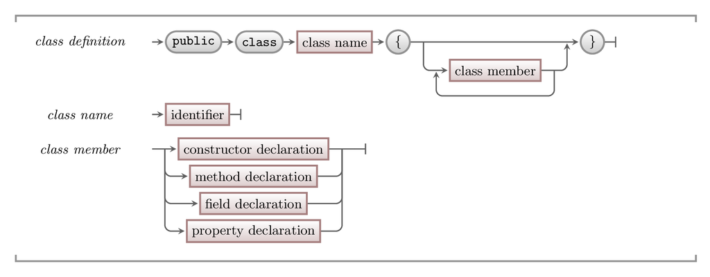

This diagram shows the syntax for declaring a class with instance members.

The following code snippet is of a `Shape` class with 2 private instance members, an `int x`, `int y`, as well as a `public void Draw()` method. This means that any objects of type `Shape` will have their own x and y integer variables, and a Draw method which they can invoke.

```
public class Shape
{
  private int _x;
  private int _y;

  public void Draw()
  {
    // ...
  }
}
```

## Constructors

This diagram shows the syntax for declaring constructor:

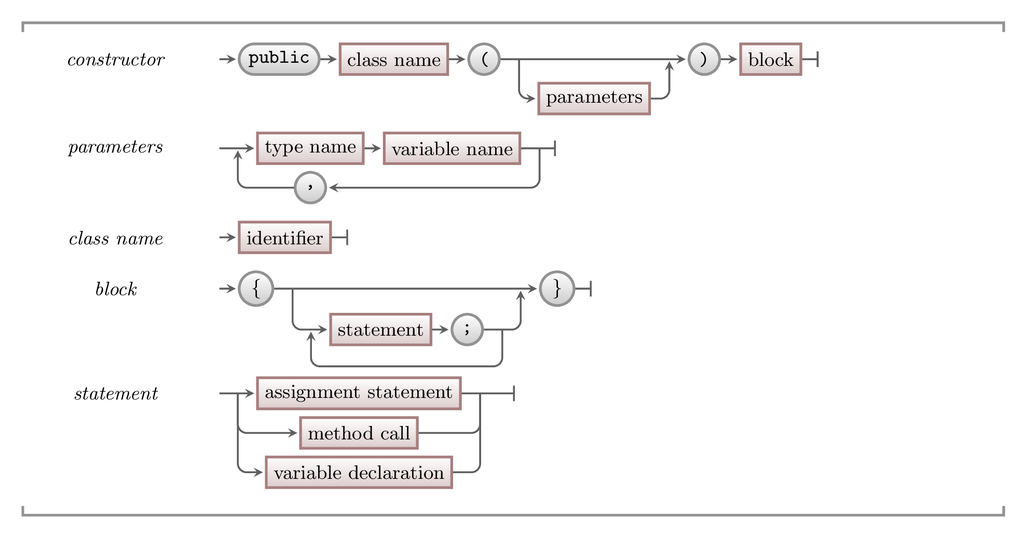

This diagram shows the syntax for declaring constructor.

Constructors are called when an object is created to provide a time to setup and initialise the object.

```
public class Shape
{
  private int _x;
  private int _y;

  public Shape(int x, int y)
  {
    _x = x;
    _y = y;
  }
}
```

Constructors can require parameters, in the code example above the constructor requires two integer (`int`) parameters.

```
public class Shape
{
  public string Name = "Shawn";
  private int _x;
  private int _y;

  public void Draw()
  {
    // ...
  }
}
```

## Instance method declaration

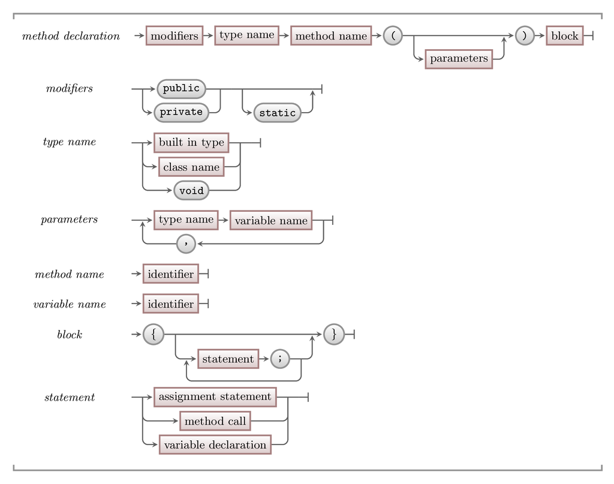

This diagram shows the syntax for declaring methods.

Instance methods are method which an object will have access to. The syntax diagram goes through sum of the modifiers for an instance method. A brief description of the modifiers follows at the end of this guide.

- All methods require a pair of braces `()` for parameters, even if a method requires no parameters. Parameters are `type identifier`, separated by comma- have a look at the `void Draw` method in the code example below:

```
public class Shape
{
  public void Draw(int x, int y, int w, int h)
  {
    SplashKit.DrawSquare(Color.Red, x, y, w, h);
  }

  private int CalculateSum()
  {
    // ...
  }
}
```

## Fields

This diagram shows the syntax for fields:

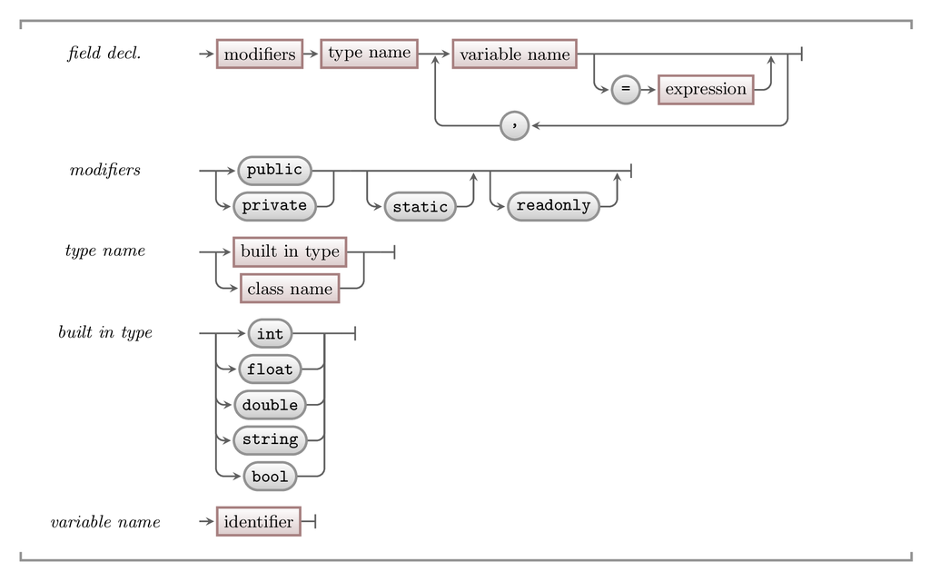

This diagram shows the syntax for fields.

Just like instance methods are "attached" to each object of a given class, *fields* are variables associated with a given class (unless they're static). Each object has it's own memory allocation for each instance field.

Having a look at the code below, it has three fields, two of which are *instance fields*. (static fields are not instance fields).

```
public class Shape
{
  public static string Name = "Shawn";
  private int _x;
  private int _y;
}
```

Let's take a look at the `public static string name = "Shawn";`. * firstly, the `public` modifier, which means any code which has a reference to it can access and change it. * the `static` modifier means that the field's memory is shared across all `Shape` objects. * `string` is the type of the field. * Lastly, it is assigned the value `"Shawn"`.

## Properties

Properties are "accessors" to an objects private fields. They can either just return the value of the field, or perform a calculation/expression.

properties are helpful because they act as accessors to fields. This means they provide ways for us to control how much access they have to a field.

This diagram shows the syntax for properties:

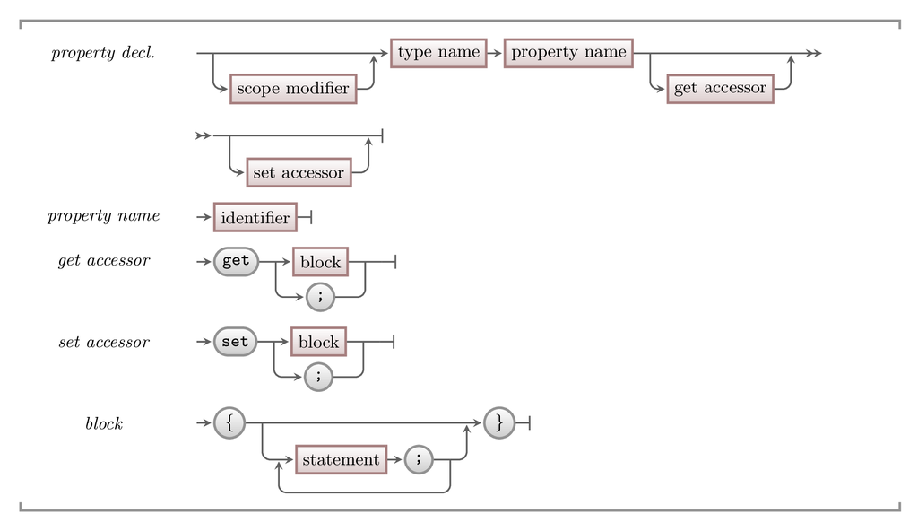

This diagram shows the syntax for properties.

```
public class Shape()
{
  private int _x;
  public int X
  {
    get {return _x};
    set { _x = value };
  }
}
```

The `get` and `set` keywords tell us that this property has access to getting and setting the field.

A common pattern is to omit the `set`, which says that this field is `readonly`:

```
public class Shape()
{
  private int _x;
  public int X
  {
    get {return _x};
  }
}
```

We can also use **auto-implemented properties**, which are a helpful and quicker way to create a field and property. The following code will have a public `X` property, and a private field.

```
public class Shape()
{
  public int X { get; set; }
}
```

## Local Variables

Local variables are variables which are declared within a class's method. In the code example below we can see some local variables in the Main() method.

*Note*: that any code outside of Main() cannot access the variables - hence why they're called local!

```
public class Shape
{
  private int x; //instance field
  private int y; //instance field

  public static void Main()
  {
    int i = 0; //local variable
    string name = "Fred"; //local variable
  }
}
```

This diagram shows the syntax for declaring variables in our code:

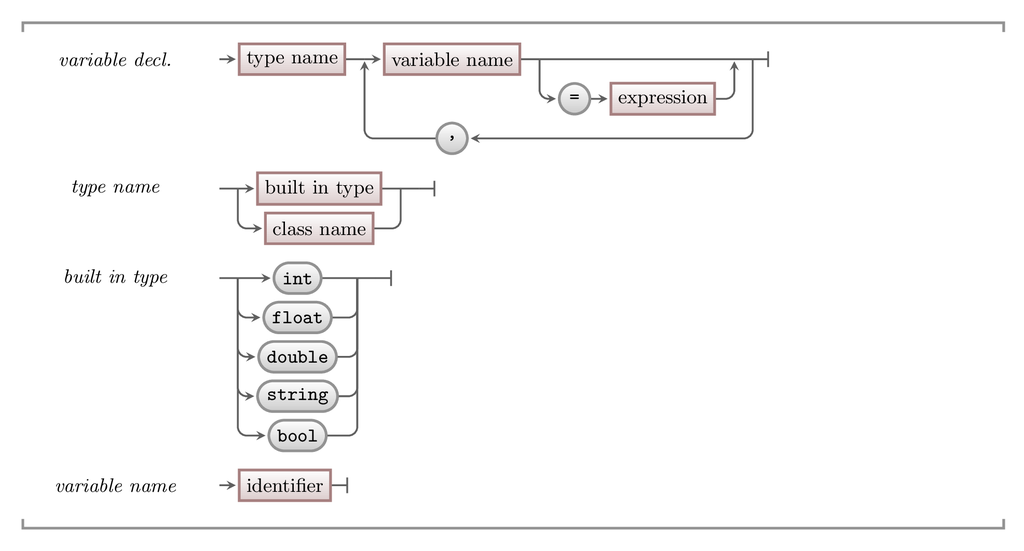

This diagram shows the syntax for declaring variables in our code.

## Return statement

Returning is an important part of our methods, it's how we signal that the method as finished doing its job, and if the method is a function, it let's us know which value to return to the caller.

This diagram shows the syntax for returning in our code:

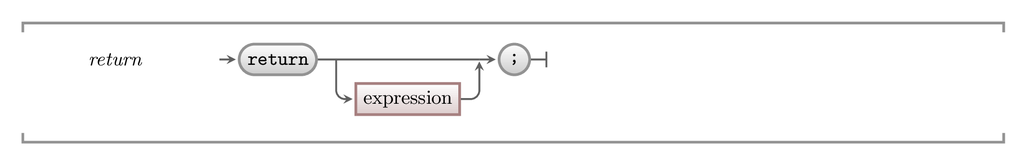

This diagram shows the syntax for returning in our code.

There are a few things to note when returning: * Void methods don't return a value, just use the return statement: ie `return;`. * You must return a value who's type matches the return type of the method, ie: * You can return any value of the correct type, so you can can return a variable (`return name;`), literal value (`return 3;`), or calculation (`return x + 50/2;`). The expression is evaluated, and then returned.

```
string GetName()
{
  return "John"; // "John" is a string, good :)
}

string GetName()
{
  return 3; // 3 is not a string, won't work :(
}
```

# Example program

We've covered a lot of new syntax this week, why don't you have a look at the following example program and try and identify all of the pieces of syntax we've spoken about?

```
using System;
using SplashKitSDK;

public class Program
{
  public static void Main()
  {
    Window w = new Window(...);
    StorageTank tnk = new StorageTank(100.0, 27.5, 10, 10, 70, 200);
  }
}

public class StorageTank
{
  private Color _liquidColor = Color.Blue;
  private readonly double _capacity;
  private double _level;

  private int _x, _y;
  private int _width, _height;

  public StorageTank(double capacity, double startLevel, int x, int y, int width, int height)
  {
    _x = x;
    _y = y;
    _width = width;
    _height = height;

    _capacity = capacity;
    _level = startLevel;
  }

  public Color LiquidColor
  {
    get { return _liquidColor; }
    set { _liquidColor = value; }
  }

  public double Capacity
  {
    get { return _capacity; }
  }

  public double Level
  {
    get { return _level; }
  }

  public double PercentFull
  {
    get { return _level / _capacity; }
  }

  public void AddLiquid(double amount)
  {
    _level = _level + amount;
  }

  public void TakeLiquid(double amount)
  {
    _level = _level - amount;
  }

  public void Draw(Window w)
  {
    double topY = y + height - height * PercentFull;
    w.FillRectangle(LiquidColor, x, topY, x + width, y + height);
    w.DrawRectangle(Color.Black, x, y, x + width, y + height);
  }
}
```

# Modifier Keywords Cheat Sheet

- **public**: Any class which references the object has access.
- **private**: Accessible only within the body of the class in which they are declared.
- **static**: Declares a member that belongs to the type itself instead of to a specific object.

There are other modifiers, which we'll take a look at in other weeks. See the [msdn reference](https://msdn.microsoft.com/en-us/library/6tcf2h8w.aspx) for further information.